# Twitter Sentiment Analysis

**Sorce of Dataset**: https://www.kaggle.com/datasets/arkhoshghalb/twitter-sentiment-analysis-hatred-speech?resource=download

## First: I will import the necessary laibraries

```python
# importing all the necessary libraries used in the project
# database manipulation libraries
import pandas as pd
import numpy as np

# visaulization libraries
import matplotlib.pyplot as plt
import seaborn as sns
from wordcloud import WordCloud

# text manipulation and natural language processing libraries
import re
import string
import nltk

# warning libraries
import warnings
%matplotlib inline
warnings.filterwarnings('ignore')

# text preprocessing libraries
from nltk.stem import PorterStemmer
from nltk.stem import WordNetLemmatizer
from wordcloud import WordCloud
from sklearn.feature_extraction.text import CountVectorizer
from sklearn.feature_extraction.text import TfidfVectorizer

# model building libraries
from sklearn.model_selection import train_test_split
from sklearn.svm import SVC
from sklearn.tree import DecisionTreeClassifier
from sklearn.model_selection import GridSearchCV
from sklearn.linear_model import LogisticRegression
from sklearn.neighbors import KNeighborsClassifier
from sklearn.ensemble import RandomForestClassifier

# model evaluation libraries
import sklearn
from sklearn.metrics import accuracy_score, confusion_matrix, precision_recall_fscore_support
from sklearn.metrics import f1_score, accuracy_score
```

## Second I will be Loading the dataset

```python
# reading the csv file
df = pd.read_csv('train.csv')

# printing the first five rows of the dataset
df.head()
```

|  | id | label | tweet |
| --- | --- | --- | --- |
| 0 | 1 | 0 | @user when a father is dysfunctional and is s... |
| 1 | 2 | 0 | @user @user thanks for #lyft credit i can't us... |
| 2 | 3 | 0 | bihday your majesty |
| 3 | 4 | 0 | #model i love u take with u all the time in ... |
| 4 | 5 | 0 | factsguide: society now #motivation |

### Looking at the dataframe's shape to see the size of our dataset

```python
# printing the shape of the dataframe
df.shape
```

```
(31962, 3)
```

### Looking at the dataframe's information to get general view about the data types

```python
# printing the dataframe information
df.info()
```

```
<class 'pandas.core.frame.DataFrame'>
RangeIndex: 31962 entries, 0 to 31961
Data columns (total 3 columns):
 #   Column  Non-Null Count  Dtype
---  ------  --------------  -----
 0   id      31962 non-null  int64
 1   label   31962 non-null  int64
 2   tweet   31962 non-null  object
dtypes: int64(2), object(1)
memory usage: 749.2+ KB
```

## Comments

1. The sentiment labels of the tweets are: 0 = positive sentiment. 1 = negative sentiment.
2. The data contains 31962 rows and 3 columns
3. The dataset has two columns with integer data types and one column with an object data type. Regarding the object data type, I will treat it as a string. Next, I will focus on the "tweets" column and proceed with the necessary pre-processing steps.

## Preprocessing the dataset

## Drop the id column

```python
df.drop('id', axis = 1, inplace = True)
```

#### Remove all twitter handles that start with @

```python
# function to remove all the handles from the tweets
def remove_pattern(input_txt, pattern):
    r = re.findall(pattern, input_txt)
    for word in r:
        input_txt = re.sub(word, "", input_txt)
    return input_txt
```

#### Creating new column with update and see the result

```python
# applying the function on the tweets
df['updated_tweet'] = np.vectorize(remove_pattern)(df['tweet'], "@[\w]*")

# printing the first five rows of the dataset
df.head()
```

|  | label | tweet | updated_tweet |
| --- | --- | --- | --- |
| 0 | 0 | @user when a father is dysfunctional and is s... | when a father is dysfunctional and is so sel... |
| 1 | 0 | @user @user thanks for #lyft credit i can't us... | thanks for #lyft credit i can't use cause th... |
| 2 | 0 | bihday your majesty | bihday your majesty |
| 3 | 0 | #model i love u take with u all the time in ... | #model i love u take with u all the time in ... |
| 4 | 0 | factsguide: society now #motivation | factsguide: society now #motivation |

```python
# removing the symbols and special characters using the replace function
df['updated_tweet'] = df['updated_tweet'].str.replace("[^a-zA-Z#]", " ")

# printing the first five rows of the dataset
df.head()
```

|  | label | tweet | updated_tweet |
| --- | --- | --- | --- |
| 0 | 0 | @user when a father is dysfunctional and is s... | when a father is dysfunctional and is so sel... |
| 1 | 0 | @user @user thanks for #lyft credit i can't us... | thanks for #lyft credit i can't use cause th... |
| 2 | 0 | bihday your majesty | bihday your majesty |
| 3 | 0 | #model i love u take with u all the time in ... | #model i love u take with u all the time in ... |
| 4 | 0 | factsguide: society now #motivation | factsguide: society now #motivation |

### Remove words that are shorts

```python
# removing words that are less than 3 characters long
df['updated_tweet'] = df['updated_tweet'].apply(lambda x: " ".join([w for w in x.split() if len(w)>3]))

# printing the first five rows of the dataset
df.head()
```

|  | label | tweet | updated_tweet |
| --- | --- | --- | --- |
| 0 | 0 | @user when a father is dysfunctional and is s... | when father dysfunctional selfish drags kids i... |
| 1 | 0 | @user @user thanks for #lyft credit i can't us... | thanks #lyft credit can't cause they don't off... |
| 2 | 0 | bihday your majesty | bihday your majesty |
| 3 | 0 | #model i love u take with u all the time in ... | #model love take with time urð±!!! ððð... |
| 4 | 0 | factsguide: society now #motivation | factsguide: society #motivation |

### Tweets tokenization

In the process of tokenizing tweets, I aim to break down all sentences into individual words. This step is important because it makes the text more manageable for further analysis.

```python
tokenized_tweet = df['updated_tweet'].apply(lambda x: x.split())

# printing the first five rows of the dataset
tokenized_tweet.head()
```

```
0    [when, father, dysfunctional, selfish, drags, ...
1    [thanks, #lyft, credit, can't, cause, they, do...
2                              [bihday, your, majesty]
3    [#model, love, take, with, time, urð±!!!, ð...
4                  [factsguide:, society, #motivation]
Name: updated_tweet, dtype: object
```

### When we used stemming, we striped off the extra parts of words to get to their basic form. This made all the words look similar and simplified

```python
# creating a stemmer object
stemmer = PorterStemmer()
tokenized_tweet = tokenized_tweet.apply(lambda sentence: [stemmer.stem(word) for word in sentence])

# printing the first five rows of the dataset
tokenized_tweet.head()
```

```
0    [when, father, dysfunct, selfish, drag, kid, i...
1    [thank, #lyft, credit, can't, caus, they, don'...
2                              [bihday, your, majesti]
3    [#model, love, take, with, time, urð±!!!, ð...
4                       [factsguide:, societi, #motiv]
Name: updated_tweet, dtype: object
```

### Combine the words

```python
for i in range(len(tokenized_tweet)):
    tokenized_tweet[i] = " ".join(tokenized_tweet[i])

df['updated_tweet'] = tokenized_tweet

# printing the first five rows of the dataset
df.head()
```

|  | label | tweet | updated_tweet |
| --- | --- | --- | --- |
| 0 | 0 | @user when a father is dysfunctional and is s... | when father dysfunct selfish drag kid into dys... |
| 1 | 0 | @user @user thanks for #lyft credit i can't us... | thank #lyft credit can't caus they don't offer... |
| 2 | 0 | bihday your majesty | bihday your majesti |
| 3 | 0 | #model i love u take with u all the time in ... | #model love take with time urð±!!! ððð... |
| 4 | 0 | factsguide: society now #motivation | factsguide: societi #motiv |

## Exploratory Data Analysis

### I will find out which words are used a lot in our data. First,I will gather all the words. Then, I will create a picture using imshow that shows the most common words.

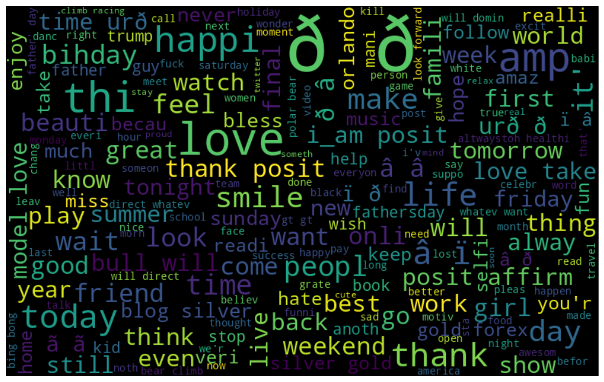

```python
# creating a wordcload of all the tweets
all_words = " ".join([sentence for sentence in df['updated_tweet']])

wordcloud = WordCloud(width=800, height=500, random_state=42, max_font_size=100).generate(all_words)
plt.figure(figsize=(15,8))
plt.imshow(wordcloud, interpolation='bilinear')
plt.axis('off')
plt.show()
```

### comment:It's clear that biger words like 'Love', occur more frequently

## First:Show a picture that highlights words associated with positivity."

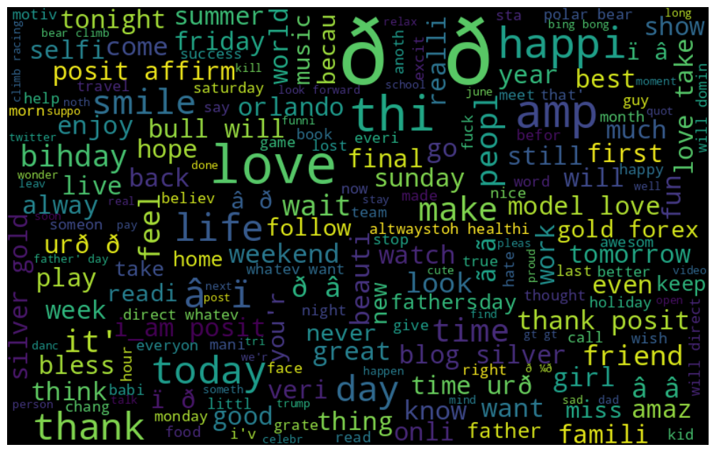

```python
# creating a wordcload of all the positive tweets
all_words = " ".join([sentence for sentence in df['updated_tweet'][df['label']==0]])
wordcloud = WordCloud(width=800, height=500, random_state=42, max_font_size=100).generate(all_words)

# Plotting
plt.figure(figsize=(15,8))
plt.imshow(wordcloud, interpolation='bilinear')
plt.axis('off')
plt.show()
```

### comment:as we can see the positive words such as (Love, today,thank,etc)

## Second: Show a picture that highlights words associated with negativity.

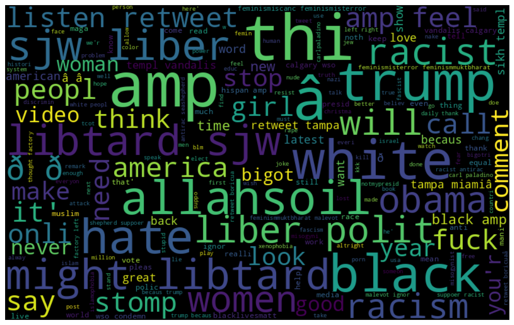

```python
# creating a wordcload of all the negative tweets
all_words = " ".join([sentence for sentence in df['updated_tweet'][df['label']==1]])
wordcloud = WordCloud(width=800, height=500, random_state=42, max_font_size=100).generate(all_words)

# plotting
plt.figure(figsize=(15,8))
plt.imshow(wordcloud, interpolation='bilinear')
plt.axis('off')
plt.show()
```

### comment:as we see some of the racist and sexist words such as (black,women ,etc) were associated with negative tweets

## Extract the # from the tweets

```python
# function to extract all the hashtags
def hashtag_extract(tweets):
    hashtags = []
    for tweet in tweets:
        ht = re.findall(r"#(\w+)", tweet)
        hashtags.append(ht)
    return hashtags
```

## Extract the positive # from tweets

### I am doing this just to find out the different hashtags in the tweets and check if there is a pattern

```python
# extracting the positive hashtags
P_hashtag = hashtag_extract(df['updated_tweet'][df['label']==0])
```

### Extract the negative # from tweets

```python
# extracting the positive hashtags
N_hashtag = hashtag_extract(df['updated_tweet'][df['label']==1])
```

### Combining the the words

```python
# combining all the tags
P_hashtag = sum(P_hashtag, [])
N_hashtag = sum(N_hashtag, [])
```

```python
# printing the hashtags of the positive tweets
P_hashtag[:6]
```

```
['run', 'lyft', 'disapoint', 'getthank', 'model', 'motiv']
```

```python
# printing the hashtags of the negative tweets
N_hashtag[:6]
```

```
['cnn', 'michigan', 'tcot', 'australia', 'opkillingbay', 'seashepherd']
```

## I use NLTK dictionary to process the tweets

```python
# creating a dataframe with the hastags and their frequencies
freq = nltk.FreqDist(P_hashtag)
d = pd.DataFrame({'Hashtag': list(freq.keys()), 'Count': list(freq.values())})

# priting the first 5 rows of the dataframe
d.head(10)
```

|  | Hashtag | Count |
| --- | --- | --- |
| 0 | run | 70 |
| 1 | lyft | 2 |
| 2 | disapoint | 1 |
| 3 | getthank | 2 |
| 4 | model | 374 |
| 5 | motiv | 195 |
| 6 | allshowandnogo | 1 |
| 7 | school | 27 |
| 8 | exam | 8 |
| 9 | hate | 26 |

### Ranking and visulizing the top 10 tweets with positive sentiments

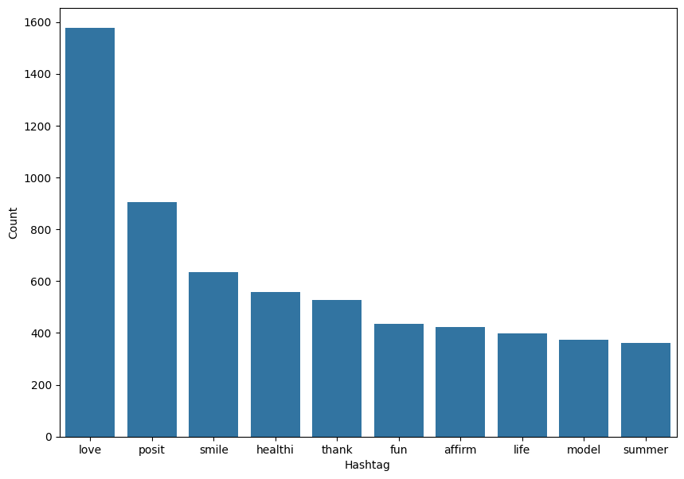

```python
# plotting the dataframe
d = d.nlargest(columns='Count', n=10)
plt.figure(figsize=(10,7))
sns.barplot(data=d, x='Hashtag', y='Count')
plt.show()
```

```python
# creating a dataframe with the hastags and their frequencies
freq = nltk.FreqDist(N_hashtag)
d = pd.DataFrame({'Hashtag': list(freq.keys()), 'Count': list(freq.values())})

# priting the first 5 rows of the dataframe
d.head(10)
```

|  | Hashtag | Count |
| --- | --- | --- |
| 0 | cnn | 9 |
| 1 | michigan | 2 |
| 2 | tcot | 14 |
| 3 | australia | 6 |
| 4 | opkillingbay | 2 |
| 5 | seashepherd | 22 |
| 6 | helpcovedolphin | 3 |
| 7 | thecov | 4 |
| 8 | neverump | 6 |
| 9 | xenophobia | 12 |

### Ranking and visulizing the top 10 tweets with negative sentiments

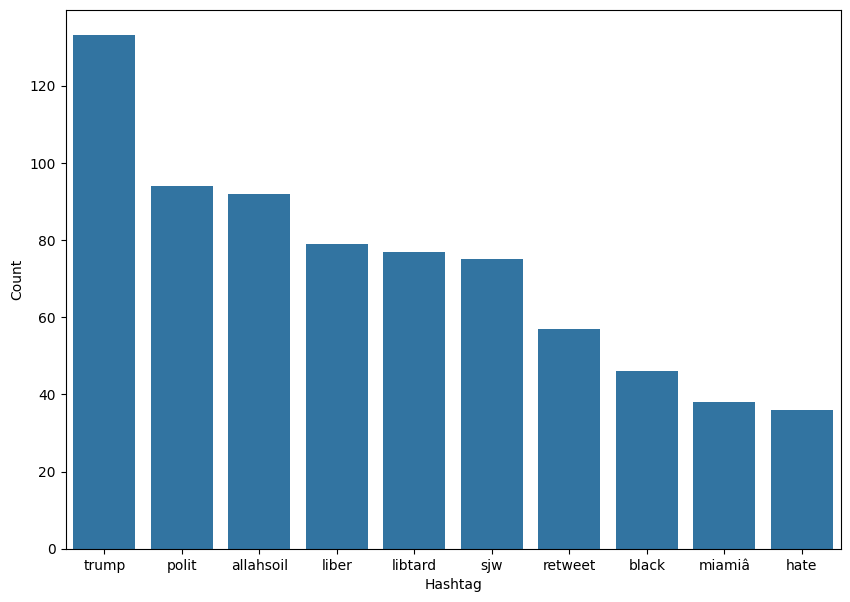

```python
# plotting the dataframe
d = d.nlargest(columns='Count', n=10)
plt.figure(figsize=(10,7))
sns.barplot(data=d, x='Hashtag', y='Count')
plt.show()
```

## Feature engineering

Feature engineering is a crucial step in preparing our data for machine learning. Since machines can not directly understand words or text, we need to convert them into vectors. In this process, Iwill use TF-IDF, a technique that often provides better accuracy compared to other vectorization methods in NLP.

As part of this vectorization technique:

### Vectroization using TF-IDF

```python
# creating a vectorizer object
vectorizer = TfidfVectorizer(min_df=3,  stop_words='english')

# fitting and transforming the tweets using the vectorizer object
vectorizer.fit(df['updated_tweet'])
tweets_df = vectorizer.transform(df["updated_tweet"])
```

### Spilt to Train and Test sets

```python
# splitting the data into training and testing datasets
x_train, x_test, y_train, y_test = train_test_split(tweets_df, df['label'],  random_state=42, test_size=0.25)
```

## Model Selection and hyperparameter tuning

### Decision Trees

```python
# defining the parameter grid
params = {'criterion':('gini','entropy'),
          'max_depth': range(1, 15)}

# creating the Grid Search object
decision_tree_model = GridSearchCV(DecisionTreeClassifier(), params, scoring="accuracy", cv=5, n_jobs=-1)
decision_tree_model.fit(x_train, y_train)

print(f'Accuracy of decision tree classifier is: {decision_tree_model. best_score_}')
print(f'best hyper parameters are: {decision_tree_model.best_params_}')
```

```
Accuracy of decision tree classifier is: 0.9461849905360497
best hyper parameters are: {'criterion': 'gini', 'max_depth': 14}
```

### SVM

```python
# defining the parameter grid
params = {"kernel": ["linear", "rbf", "poly"],
          "C": [0.1, 0.5, 1, 1.5, 2]}

# creating the Grid Search object
svm_model = GridSearchCV(SVC(), params, scoring="accuracy", cv=5, n_jobs=-1)
svm_model.fit(x_train, y_train)

print("Accuracy of SVM classfier = {:.2f}".format(svm_model.best_score_))
print("Best found hyperparameters of SVM classifier = {}".format(svm_model.  best_params_))
```

```
Accuracy of SVM classfier = 0.96
Best found hyperparameters of SVM classifier = {'C': 2, 'kernel': 'rbf'}
```

### Random Forest

```python
# defining the parameter grid
params = {'criterion':['gini', 'entropy'],
          'max_depth':range(1, 3)}

# creating the Grid Search object
rf_model = GridSearchCV(RandomForestClassifier(), params, scoring='accuracy', cv=5, n_jobs = -1)
rf_model.fit(x_train, y_train)

print("Accuracy of SVM classfier = {:.2f}".format(rf_model.best_score_))
print("Best found hyperparameters of SVM classifier = {}".format(rf_model.  best_params_))
```

```
Accuracy of SVM classfier = 0.93
Best found hyperparameters of SVM classifier = {'criterion': 'gini', 'max_depth': 1}
```

### K-Neighbors Classifier

```python
# defining the hyperparameters
params = {"n_neighbors": range(1, 10), "weights": ['uniform', 'distance']}

kn_model = GridSearchCV(KNeighborsClassifier(), params, scoring='accuracy', cv=5, n_jobs=-1)

# training the model
kn_model.fit(x_train, y_train)

# Checking accuracy of the model and the best hyperparameters
best_accuracy = kn_model.best_score_
best_params = kn_model.best_params_

print("Accuracy of best K-Nearest Neighbors model = {:.2%}".format(best_accuracy))
print("Best hyperparameters for the model =", best_params)
```

```
Accuracy of best K-Nearest Neighbors model = 94.88%
Best hyperparameters for the model = {'n_neighbors': 3, 'weights': 'distance'}
```

### Comparing the acuracy for the models by printing them here

```python
print(f'Accuracy of Decision Tree classifier is: {decision_tree_model.  best_score_}')
print(f'Accuracy of SVM classfier is: {svm_model.best_score_}')
print(f'Accuracy of Random Forest classfier is: {rf_model.best_score_}')
print(f'Accuracy of K Nearest Neighbors classfier is: {kn_model.best_score_}')
```

```
Accuracy of Decision Tree classifier is: 0.9461849905360497
Accuracy of SVM classfier is: 0.9624129658075375
Accuracy of Random Forest classfier is: 0.9297901661052681
Accuracy of K Nearest Neighbors classfier is: 0.9488132410908143
```

### Comparing the acuracy for the models by printing them here

## Model evaluation

```
Accuracy = 0.9609560755850332
Precision = [0.96366241 0.89456869]
Recall = [0.99555974 0.50089445]
F1-Score = [0.97935142 0.64220183]
Confusion Matrix:
 [[7399   33]
 [ 279  280]]
```

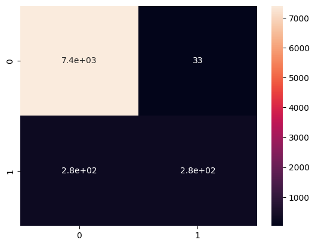

```python
# evaluating the model performances
y_predicted = svm_model.predict(x_test)
accuracy = sklearn.metrics.accuracy_score(y_test, y_predicted)
cm = sklearn.metrics.confusion_matrix(y_test, y_predicted)
precision, recall, f1, support = precision_recall_fscore_support(y_test, y_predicted)


print("Accuracy =", accuracy)
print("Precision =", precision)
print("Recall =", recall)
print("F1-Score =", f1)
print("Confusion Matrix:\n", cm)
sns.heatmap(cm, annot=True)
```

## Finding the sentiments of the tweets in the test set

The test data in the original dataset contaiined a test set that did not have any sentiments. The best model can be used to generate the new sentiments

```python
test = pd.read_csv('test.csv')
test.drop('id', axis = 1, inplace = True)
```

## Preprocessing the dataset

#### Remove all twitter handles that start with @

```python
# function to remove all the handles from the tweets
def remove_pattern(input_txt, pattern):
    r = re.findall(pattern, input_txt)
    for word in r:
        input_txt = re.sub(word, "", input_txt)
    return input_txt
```

#### Creating new column with update and see the result

```python
# applying the function on the tweets
test['updated_tweet'] = np.vectorize(remove_pattern)(test['tweet'], "@[\w]*")

# printing the first five rows of the dataset
test.head()
```

|  | tweet | updated_tweet |
| --- | --- | --- |
| 0 | #studiolife #aislife #requires #passion #dedic... | #studiolife #aislife #requires #passion #dedic... |
| 1 | @user #white #supremacists want everyone to s... | #white #supremacists want everyone to see th... |
| 2 | safe ways to heal your #acne!! #altwaystohe... | safe ways to heal your #acne!! #altwaystohe... |
| 3 | is the hp and the cursed child book up for res... | is the hp and the cursed child book up for res... |
| 4 | 3rd #bihday to my amazing, hilarious #nephew... | 3rd #bihday to my amazing, hilarious #nephew... |

```python
# removing the symbols and special characters using the replace function
test['updated_tweet'] = test['updated_tweet'].str.replace("[^a-zA-Z#]", " ")

# printing the first five rows of the dataset
test.head()
```

|  | tweet | updated_tweet |
| --- | --- | --- |
| 0 | #studiolife #aislife #requires #passion #dedic... | #studiolife #aislife #requires #passion #dedic... |
| 1 | @user #white #supremacists want everyone to s... | #white #supremacists want everyone to see th... |
| 2 | safe ways to heal your #acne!! #altwaystohe... | safe ways to heal your #acne!! #altwaystohe... |
| 3 | is the hp and the cursed child book up for res... | is the hp and the cursed child book up for res... |
| 4 | 3rd #bihday to my amazing, hilarious #nephew... | 3rd #bihday to my amazing, hilarious #nephew... |

### Remove words that are shorts

```python
# removing words that are less than 3 characters long
test['updated_tweet'] = test['updated_tweet'].apply(lambda x: " ".join([w for w in x.split() if len(w)>3]))

# printing the first five rows of the dataset
test.head()
```

|  | tweet | updated_tweet |
| --- | --- | --- |
| 0 | #studiolife #aislife #requires #passion #dedic... | #studiolife #aislife #requires #passion #dedic... |
| 1 | @user #white #supremacists want everyone to s... | #white #supremacists want everyone #birdsâ #... |
| 2 | safe ways to heal your #acne!! #altwaystohe... | safe ways heal your #acne!! #altwaystoheal #he... |
| 3 | is the hp and the cursed child book up for res... | cursed child book reservations already? yes, w... |
| 4 | 3rd #bihday to my amazing, hilarious #nephew... | #bihday amazing, hilarious #nephew ahmir! uncl... |

### Tweets tokenization

In the process of tokenizing tweets, I aim to break down all sentences into individual words. This step is important because it makes the text more manageable for further analysis.

```python
tokenized_tweet = test['updated_tweet'].apply(lambda x: x.split())

# printing the first five rows of the dataset
tokenized_tweet.head()
```

```
0    [#studiolife, #aislife, #requires, #passion, #...
1    [#white, #supremacists, want, everyone, #birds...
2    [safe, ways, heal, your, #acne!!, #altwaystohe...
3    [cursed, child, book, reservations, already?, ...
4    [#bihday, amazing,, hilarious, #nephew, ahmir!...
Name: updated_tweet, dtype: object
```

### Tweets Stemming

When we used stemming, we striped off the extra parts of words to get to their basic form. This made all the words look similar and simplified

```python
# creating a stemmer object
stemmer = PorterStemmer()
tokenized_tweet = tokenized_tweet.apply(lambda sentence: [stemmer.stem(word) for word in sentence])

# printing the first five rows of the dataset
tokenized_tweet.head()
```

```
0    [#studiolif, #aislif, #requir, #passion, #dedi...
1    [#white, #supremacist, want, everyon, #birdsâ...
2    [safe, way, heal, your, #acne!!, #altwaystoh, ...
3    [curs, child, book, reserv, already?, yes,, wh...
4    [#bihday, amazing,, hilari, #nephew, ahmir!, u...
Name: updated_tweet, dtype: object
```

### Combine the words

```python
for i in range(len(tokenized_tweet)):
    tokenized_tweet[i] = " ".join(tokenized_tweet[i])

test['updated_tweet'] = tokenized_tweet

# printing the first five rows of the dataset
test.head()
```

|  | tweet | updated_tweet |
| --- | --- | --- |
| 0 | #studiolife #aislife #requires #passion #dedic... | #studiolif #aislif #requir #passion #dedic #wi... |
| 1 | @user #white #supremacists want everyone to s... | #white #supremacist want everyon #birdsâ #mo... |
| 2 | safe ways to heal your #acne!! #altwaystohe... | safe way heal your #acne!! #altwaystoh #health... |
| 3 | is the hp and the cursed child book up for res... | curs child book reserv already? yes, where? wh... |
| 4 | 3rd #bihday to my amazing, hilarious #nephew... | #bihday amazing, hilari #nephew ahmir! uncl da... |

### Vectorization using TF-IDF

```python
# creating a vectorizer object
# vectorizer = TfidfVectorizer(min_df=3,  stop_words='english')

# fitting and transforming the tweets using the vectorizer object
# vectorizer.fit(test['updated_tweet'])
test_tweets_df = vectorizer.transform(test["updated_tweet"])
```

### Predicting the new sentiments

```python
# evaluating the model performances
y_predicted = svm_model.predict(test_tweets_df)
```

```python
# appending the predicted sentiments to the data
test['Sentiment'] = y_predicted

# printing the first 10 rows of the dataset
test.head(10)
```

|  | tweet | updated_tweet | Sentiment |
| --- | --- | --- | --- |
| 0 | #studiolife #aislife #requires #passion #dedic... | #studiolif #aislif #requir #passion #dedic #wi... | 0 |
| 1 | @user #white #supremacists want everyone to s... | #white #supremacist want everyon #birdsâ #mo... | 0 |
| 2 | safe ways to heal your #acne!! #altwaystohe... | safe way heal your #acne!! #altwaystoh #health... | 0 |
| 3 | is the hp and the cursed child book up for res... | curs child book reserv already? yes, where? wh... | 0 |
| 4 | 3rd #bihday to my amazing, hilarious #nephew... | #bihday amazing, hilari #nephew ahmir! uncl da... | 0 |
| 5 | choose to be :) #momtips | choos #momtip | 0 |
| 6 | something inside me dies ð¦ð¿â¨ eyes nes... | someth insid die ð¦ð¿â¨ eye ness #smokeye... | 0 |
| 7 | #finished#tattoo#inked#ink#loveitâ¤ï¸ #â¤ï¸... | #finished#tattoo#inked#ink#loveitâ¤ï¸ #â¤ï¸... | 0 |
| 8 | @user @user @user i will never understand why... | will never understand left when young.... #dee... | 0 |
| 9 | #delicious #food #lovelife #capetown mannaep... | #delici #food #lovelif #capetown mannaepicur #... | 0 |

## Conclusion

### Limitation

1. Although I looked at some text preprocesssing techniques, other texts might produce better accuracies and evaluation scores of the best models (or other models).
2. Other advanced models that were not tested here could probably be a better fit and produce better evaluation scores.

### Strength

Different models were tested on the data to find out which one is the best

### Implication

The best model can be used to predict the sentiments of new tweets that are generated.